**Apply KNN algorithm to predict heart disease**

```python
import pandas as pd #Import Required Libraries
import numpy as np

import matplotlib.pyplot as plt

from sklearn.model_selection import train_test_split
from sklearn.preprocessing import StandardScaler
from sklearn.neighbors import KNeighborsClassifier
from sklearn.metrics import accuracy_score, confusion_matrix, classification_report
```

```python
#Load Dataset
df = pd.read_csv('/content/cleaned_merged_heart_dataset.csv')

df.head()
```

|  | age | sex | cp | trestbps | chol | fbs | restecg | thalachh | exang | oldpeak | slope | ca | thal | target |
| --- | --- | --- | --- | --- | --- | --- | --- | --- | --- | --- | --- | --- | --- | --- |
| 0 | 63 | 1 | 3 | 145 | 233 | 1 | 0 | 150 | 0 | 2.3 | 0 | 0 | 1 | 1 |
| 1 | 37 | 1 | 2 | 130 | 250 | 0 | 1 | 187 | 0 | 3.5 | 0 | 0 | 2 | 1 |
| 2 | 41 | 0 | 1 | 130 | 204 | 0 | 0 | 172 | 0 | 1.4 | 2 | 0 | 2 | 1 |
| 3 | 56 | 1 | 1 | 120 | 236 | 0 | 1 | 178 | 0 | 0.8 | 2 | 0 | 2 | 1 |
| 4 | 57 | 0 | 0 | 120 | 354 | 0 | 1 | 163 | 1 | 0.6 | 2 | 0 | 2 | 1 |

```python
#Understand Data
df.shape
df.info()
df.describe()

# Check target distribution
df['target'].value_counts()
```

```
<class 'pandas.core.frame.DataFrame'>
RangeIndex: 1888 entries, 0 to 1887
Data columns (total 14 columns):
 #   Column    Non-Null Count  Dtype
---  ------    --------------  -----
 0   age       1888 non-null   int64
 1   sex       1888 non-null   int64
 2   cp        1888 non-null   int64
 3   trestbps  1888 non-null   int64
 4   chol      1888 non-null   int64
 5   fbs       1888 non-null   int64
 6   restecg   1888 non-null   int64
 7   thalachh  1888 non-null   int64
 8   exang     1888 non-null   int64
 9   oldpeak   1888 non-null   float64
 10  slope     1888 non-null   int64
 11  ca        1888 non-null   int64
 12  thal      1888 non-null   int64
 13  target    1888 non-null   int64
dtypes: float64(1), int64(13)
memory usage: 206.6 KB
```

| target | count |
| --- | --- |
| 1 | 977 |
| 0 | 911 |

**dtype:** int64

inference : 1 = more chance of heart attack, 0 = less chance of heat attack

prompt : identify the features and target

```python
X = df.drop('target', axis=1)
y = df['target']
```

prompt: split the data into 80% training and 20% testing data

```python
X_train, X_test, y_train, y_test = train_test_split(
    X, y, test_size=0.2, random_state=42
)
```

prompt : apply feature scaling on the dataset

```python
scaler = StandardScaler()

X_train = scaler.fit_transform(X_train)
X_test = scaler.transform(X_test)
```

inference: because it's a distance based method feature scaling help to prevents dominance of large scale features

prompt: Apply KNN Algorithm with k nearest neighbour 5

```python
knn = KNeighborsClassifier(n_neighbors=5)

knn.fit(X_train, y_train)
```

```
KNeighborsClassifier()
```

prompt: predict the target for test data

```python
y_pred = knn.predict(X_test)
```

prompt: write a code to calculate the model prediction accuracy

```python
accuracy = accuracy_score(y_test, y_pred)

print("Model Accuracy:", accuracy)
```

```
Model Accuracy: 0.9021164021164021
```

inference: ~90% indicating a strong overall ability to classify instances correctly.

prompt:write code to give Confusion Matrix & classification Report

```python
print("Confusion Matrix:\n", confusion_matrix(y_test, y_pred))

print("\nClassification Report:\n", classification_report(y_test, y_pred))
```

```
Confusion Matrix:
 [[156  32]
 [  5 185]]

Classification Report:
               precision    recall  f1-score   support

           0       0.97      0.83      0.89       188
           1       0.85      0.97      0.91       190

    accuracy                           0.90       378
   macro avg       0.91      0.90      0.90       378
weighted avg       0.91      0.90      0.90       378
```

inference:The F1-scores (0.89 and 0.91) are well-balanced, suggesting the model is robust and not heavily biased toward one class despite the slight difference in recall and precision.

prompt: give code to plot the confusion matrix

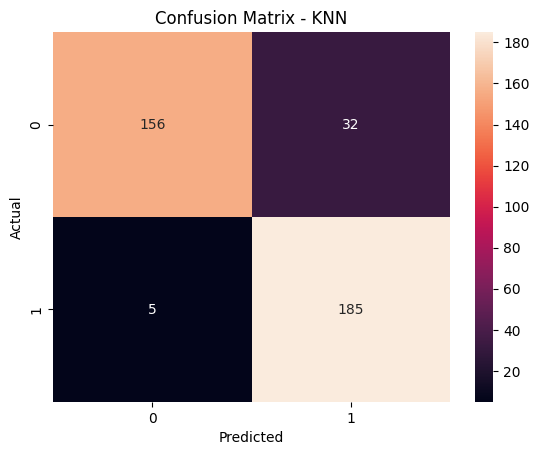

```python
import seaborn as sns
from sklearn.metrics import confusion_matrix
cm_knn = confusion_matrix(y_test, y_pred_knn)

plt.figure()
sns.heatmap(cm_knn, annot=True, fmt='d')

plt.xlabel("Predicted")
plt.ylabel("Actual")
plt.title("Confusion Matrix - KNN")

plt.show()
```

inference:Recall (Sensitivity): ~97.4%. The model is exceptionally good at identifying Class 1, missing only 5 instances (False Negatives).Precision: ~85.3%. When the model predicts Class 1, it is correct about 85% of the time, with 32 instances of Class 0 being misclassified as Class 1 (False Positives).

prompt: write code for Find Best K Value with graph ( k vs accuracy)

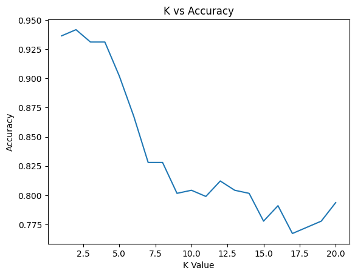

```python
accuracy_list = []

for k in range(1, 21):
    knn = KNeighborsClassifier(n_neighbors=k)
    knn.fit(X_train, y_train)
    y_pred = knn.predict(X_test)
    accuracy_list.append(accuracy_score(y_test, y_pred))

plt.plot(range(1, 21), accuracy_list)
plt.xlabel("K Value")
plt.ylabel("Accuracy")
plt.title("K vs Accuracy")
plt.show()
```

inference: Optimal K-Value: The model performs best with small values of (k). The peak accuracy (approx. 0.94-0.95) occurs when (k) is between 1 and 4. Performance Drop: There is a significant sharp decline in accuracy as (k) increases from 5 to 8, where it drops to roughly 0.825. Stability at Higher K: For (k > 10), the accuracy fluctuates within a lower range of 0.775 to 0.810.

**Apply Decition Tree algorithm to predict heart disease**

```python
from sklearn.tree import DecisionTreeClassifier # import libraries
```

prompt:Apply Decision Tree Model on the same dataset

```python
dt = DecisionTreeClassifier(random_state=42)

dt.fit(X_train, y_train)
```

```
DecisionTreeClassifier(random_state=42)
```

prompt: write code to predict the heart desease by decision tree on test data

```python
y_pred_dt = dt.predict(X_test)
```

prompt : give code for cheack the prediction accuracy

```python
from sklearn.metrics import accuracy_score

dt_accuracy = accuracy_score(y_test, y_pred_dt)
print("Decision Tree Accuracy:", dt_accuracy)
```

```
Decision Tree Accuracy: 0.9444444444444444
```

inference:the Decision Tree achieved higher accuracy than KNN.

Prompt: write code for Confusion Matrix & Report on decision tree prediction

```python
from sklearn.metrics import confusion_matrix, classification_report

print("Confusion Matrix:\n", confusion_matrix(y_test, y_pred_dt))

print("\nClassification Report:\n", classification_report(y_test, y_pred_dt))
```

```
Confusion Matrix:
 [[178  10]
 [ 11 179]]

Classification Report:
               precision    recall  f1-score   support

           0       0.94      0.95      0.94       188
           1       0.95      0.94      0.94       190

    accuracy                           0.94       378
   macro avg       0.94      0.94      0.94       378
weighted avg       0.94      0.94      0.94       378
```

inference : The model is highly reliable and shows no significant bias toward either class. It is well-suited for this dataset, though you should check for potential overfitting, as decision trees are prone to it.

prompt: give code for cheak model overfitting

```python
print("Training Accuracy (DT):", dt.score(X_train, y_train))
print("Testing Accuracy (DT):", dt.score(X_test, y_test))
```

```
Training Accuracy (DT): 1.0
Testing Accuracy (DT): 0.9444444444444444
```

inference: the model is overfitted

prompt: give code to reduce the model overfitting by control the tree growth

```python
dt = DecisionTreeClassifier(
    max_depth=5,
    min_samples_split=10,
    min_samples_leaf=5,
    random_state=42
)

dt.fit(X_train, y_train)

print("Training Accuracy:", dt.score(X_train, y_train))
print("Testing Accuracy:", dt.score(X_test, y_test))#fix overfitting
```

```
Training Accuracy: 0.8900662251655629
Testing Accuracy: 0.8544973544973545
```

inference: now the decision model generate the balanced accuracy

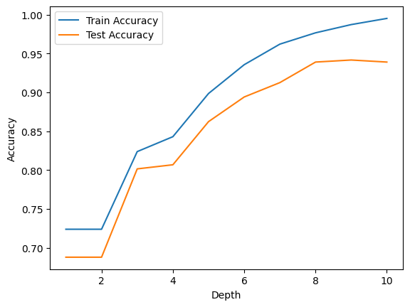

```python
depths = range(1, 11)
train_acc = []
test_acc = []

for d in depths:
    dt = DecisionTreeClassifier(max_depth=d, random_state=42)
    dt.fit(X_train, y_train)

    train_acc.append(dt.score(X_train, y_train))
    test_acc.append(dt.score(X_test, y_test))

plt.plot(depths, train_acc, label='Train Accuracy')
plt.plot(depths, test_acc, label='Test Accuracy')
plt.xlabel("Depth")
plt.ylabel("Accuracy")
plt.legend()
plt.show()
```

inference: based on the accuracy plot At low depths (below 4), both training and test accuracies are relatively low. The Optimal Depth appears to be around depth 8. This is where the test accuracy reaches its peak (approximately 0.95) and the performance stabilizes. Beyond depth 8, the training accuracy continues to climb toward 1.0, while the test accuracy plateaus. The widening gap suggests the model is starting to memorize the training data rather than generalizing.

prompt: give code to generate confusion matrix graph for afer tuning decision tree model

[figure not shown]

```python
import seaborn as sns
from sklearn.metrics import confusion_matrix
cm_dt = confusion_matrix(y_test, y_pred_dt)

plt.figure()
sns.heatmap(cm_dt, annot=True, fmt='d')

plt.xlabel("Predicted")
plt.ylabel("Actual")
plt.title("Confusion Matrix - Decision Tree")

plt.show()
```

prompt: plot a graph to Shows which factor affects heart disease most

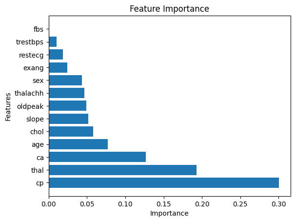

```python
import pandas as pd
import matplotlib.pyplot as plt

# Train tuned Decision Tree again
dt = DecisionTreeClassifier(max_depth=5, random_state=42)
dt.fit(X_train, y_train)

# Feature importance
importance = dt.feature_importances_

# Convert to dataframe
feature_names = X.columns
feat_imp = pd.DataFrame({'Feature': feature_names, 'Importance': importance})
feat_imp = feat_imp.sort_values(by='Importance', ascending=False)

# Plot
plt.figure()
plt.barh(feat_imp['Feature'], feat_imp['Importance'])
plt.xlabel("Importance")
plt.ylabel("Features")
plt.title("Feature Importance")
plt.show()
```

inference: Dominant Predictor: cp (chest pain) is the most significant feature, with an importance score of approximately 0.30. This suggests it is the strongest indicator used by the model to make predictions.Secondary Key Factors: thal and ca (number of major vessels) follow as the next most influential variables, indicating that physiological heart conditions are weighted more heavily than demographic data in this model.Least Influential Features: Features such as fbs (fasting blood sugar), trestbps (resting blood pressure), and restecg have nearly zero importance, suggesting they contribute very little to the model's decision-making process.

prompt: give code to generate correlation heatmap

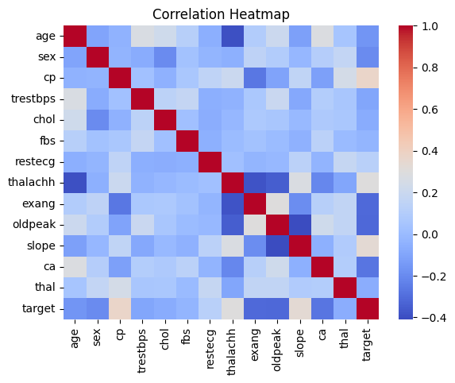

```python
import seaborn as sns

plt.figure()
sns.heatmap(df.corr(), annot=False, cmap='coolwarm')
plt.title("Correlation Heatmap")
plt.show()
```

```python
df.corr()
```

|  | age | sex | cp | trestbps | chol | fbs | restecg | thalachh | exang | oldpeak | slope | ca | thal | target |
| --- | --- | --- | --- | --- | --- | --- | --- | --- | --- | --- | --- | --- | --- | --- |
| age | 1.000000 | -0.104266 | -0.042752 | 0.271607 | 0.221379 | 0.119464 | -0.059987 | -0.392916 | 0.092343 | 0.205371 | -0.121312 | 0.283840 | 0.053396 | -0.162303 |
| sex | -0.104266 | 1.000000 | -0.035520 | -0.068685 | -0.198892 | 0.032837 | -0.031690 | -0.053983 | 0.145680 | 0.092515 | -0.020484 | 0.104863 | 0.168063 | -0.196214 |
| cp | -0.042752 | -0.035520 | 1.000000 | 0.031046 | -0.050474 | 0.060817 | 0.147336 | 0.198605 | -0.269027 | -0.109615 | 0.156571 | -0.120645 | 0.243273 | 0.371258 |
| trestbps | 0.271607 | -0.068685 | 0.031046 | 1.000000 | 0.136976 | 0.171784 | -0.056821 | -0.041222 | 0.067186 | 0.196181 | -0.084387 | 0.098762 | 0.054935 | -0.095875 |
| chol | 0.221379 | -0.198892 | -0.050474 | 0.136976 | 1.000000 | 0.024681 | -0.062365 | -0.021208 | 0.073496 | 0.058111 | -0.009180 | 0.080456 | 0.063576 | -0.071589 |
| fbs | 0.119464 | 0.032837 | 0.060817 | 0.171784 | 0.024681 | 1.000000 | -0.054344 | -0.000829 | 0.035332 | 0.000702 | -0.045836 | 0.132365 | -0.004210 | -0.032491 |
| restecg | -0.059987 | -0.031690 | 0.147336 | -0.056821 | -0.062365 | -0.054344 | 1.000000 | 0.021038 | -0.029963 | -0.016102 | 0.131779 | -0.038458 | 0.174936 | 0.123289 |
| thalachh | -0.392916 | -0.053983 | 0.198605 | -0.041222 | -0.021208 | -0.000829 | 0.021038 | 1.000000 | -0.381478 | -0.349612 | 0.277653 | -0.215914 | -0.100009 | 0.298795 |
| exang | 0.092343 | 0.145680 | -0.269027 | 0.067186 | 0.073496 | 0.035332 | -0.029963 | -0.381478 | 1.000000 | 0.299862 | -0.188768 | 0.117558 | 0.158651 | -0.315084 |
| oldpeak | 0.205371 | 0.092515 | -0.109615 | 0.196181 | 0.058111 | 0.000702 | -0.016102 | -0.349612 | 0.299862 | 1.000000 | -0.408819 | 0.221370 | 0.160869 | -0.315629 |
| slope | -0.121312 | -0.020484 | 0.156571 | -0.084387 | -0.009180 | -0.045836 | 0.131779 | 0.277653 | -0.188768 | -0.408819 | 1.000000 | -0.053255 | 0.091398 | 0.333837 |
| ca | 0.283840 | 0.104863 | -0.120645 | 0.098762 | 0.080456 | 0.132365 | -0.038458 | -0.215914 | 0.117558 | 0.221370 | -0.053255 | 1.000000 | 0.101406 | -0.273105 |
| thal | 0.053396 | 0.168063 | 0.243273 | 0.054935 | 0.063576 | -0.004210 | 0.174936 | -0.100009 | 0.158651 | 0.160869 | 0.091398 | 0.101406 | 1.000000 | -0.067322 |
| target | -0.162303 | -0.196214 | 0.371258 | -0.095875 | -0.071589 | -0.032491 | 0.123289 | 0.298795 | -0.315084 | -0.315629 | 0.333837 | -0.273105 | -0.067322 | 1.000000 |

inference: The heatmap shows relationships between features. Strong correlations help in better model prediction.

**Use Random Forest to predict heart desease**

```python
from sklearn.ensemble import RandomForestClassifier # import libraries
```

prompt: write code for apply random forest and calculate accuracy

```python
rf = RandomForestClassifier(n_estimators=100, random_state=42)
rf.fit(X_train, y_train)

y_pred_rf = rf.predict(X_test)

print("Random Forest Accuracy:", accuracy_score(y_test, y_pred_rf))
```

```
Random Forest Accuracy: 0.9576719576719577
```

inference:Random Forest improved accuracy by combining multiple decision trees and reducing overfitting.

```python
from sklearn.model_selection import cross_val_score

scores = cross_val_score(dt, X, y, cv=5)

print("Cross Validation Scores:", scores)
print("Average Accuracy:", scores.mean())
```

```
Cross Validation Scores: [0.89417989 0.87301587 0.88888889 0.80901857 0.86472149]
Average Accuracy: 0.8659649418270108
```

inference:Cross-validation ensures that the model performs consistently across different data splits.

prompt: give code for plotting roc curve

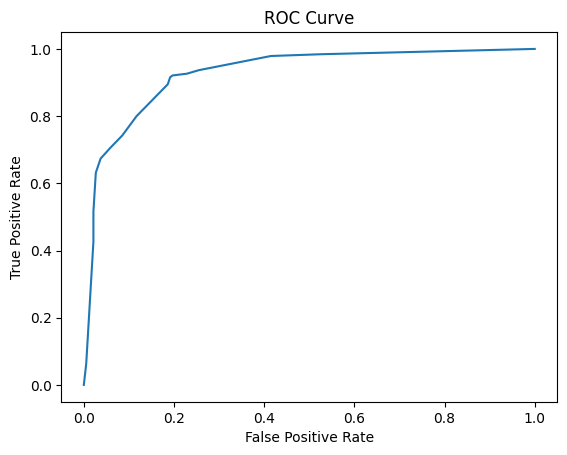

```python
from sklearn.metrics import roc_curve, auc

y_prob = dt.predict_proba(X_test)[:,1]

fpr, tpr, _ = roc_curve(y_test, y_prob)
roc_auc = auc(fpr, tpr)

plt.figure()
plt.plot(fpr, tpr)
plt.xlabel("False Positive Rate")
plt.ylabel("True Positive Rate")
plt.title("ROC Curve")
plt.show()
```

prompt: give code to plot confusion matrix on random forest prediction

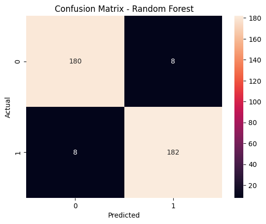

```python
import seaborn as sns
from sklearn.metrics import confusion_matrix
cm_rf = confusion_matrix(y_test, y_pred_rf)

plt.figure()
sns.heatmap(cm_rf, annot=True, fmt='d')

plt.xlabel("Predicted")
plt.ylabel("Actual")
plt.title("Confusion Matrix - Random Forest")

plt.show()
```

inference: High Reliability: The model is performing exceptionally well with very few misclassifications.Balanced Class Performance: Since the number of samples for each class is nearly equal (188 for class 0 and 190 for class 1) and the error rates are identical, the model shows no bias toward either class.Model Robustness: A 95%+ accuracy suggests that the Random Forest algorithm has captured the underlying patterns in the data effectively.

prompt: write code to run all the model collectively and compare accuracy

```python
# KNN
knn = KNeighborsClassifier(n_neighbors=5)
knn.fit(X_train, y_train)
knn_acc = knn.score(X_test, y_test)

# Decision Tree (tuned)
dt = DecisionTreeClassifier(max_depth=5, random_state=42)
dt.fit(X_train, y_train)
dt_acc = dt.score(X_test, y_test)

# Random Forest
from sklearn.ensemble import RandomForestClassifier

rf = RandomForestClassifier(n_estimators=100, random_state=42)
rf.fit(X_train, y_train)
rf_acc = rf.score(X_test, y_test)

print("KNN:", knn_acc)
print("Decision Tree:", dt_acc)
print("Random Forest:", rf_acc)
```

```
KNN: 0.9021164021164021
Decision Tree: 0.8624338624338624
Random Forest: 0.9576719576719577
```

inference: A comparison of different machine learning algorithms was performed using accuracy as the evaluation metric. Random Forest achieved the highest accuracy, followed by KNN and Decision Tree. The results indicate that ensemble methods outperform individual models.

prompt: give code to plot comparision graph for all models

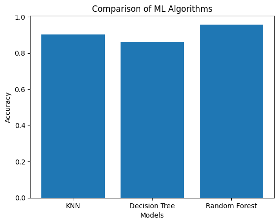

```python
import matplotlib.pyplot as plt

models = ['KNN', 'Decision Tree', 'Random Forest']
accuracies = [knn_acc, dt_acc, rf_acc]

plt.figure()
plt.bar(models, accuracies)

plt.xlabel("Models")
plt.ylabel("Accuracy")
plt.title("Comparison of ML Algorithms")

plt.show()
```

Final Inference:

Random Forest provides better performance due to its ability to reduce overfitting by combining multiple decision trees. KNN performs well based on similarity measures, while Decision Tree offers interpretability but slightly lower accuracy.